# Projekt z analizy danych

# 9 Analiza ważności atrybutów

Analiza ważności atrybutów z wytrenowanego modelu sugeruje, że zdecydowanie najważniejszym czynnikiem wplywającym na rozmiar śledzia jest temperatura wody przy powierzchni wody. Ten atrybów jest dość silnie ujemnie skorelowany z długością śledzia. Oznacza to, że głównym powodem spadku długości śledzia w czasie był wzrost temperatury przy powierzchni wody.

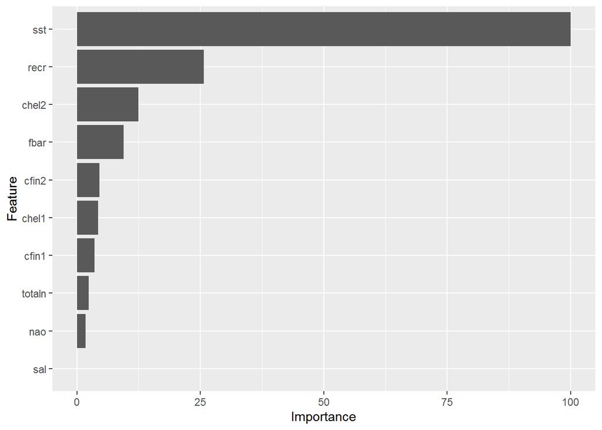

```r
ggplot(varImp(model))
```

Potwierdzimy te przypuszczenia rysując jednocześnie jak zmieniały się te dwie wartości w czasie. W tym celu wyciągam średnie z dłuższych okresów dla temperatury przy powierzchi, analogicznie jak wcześniej dla długości śledzia.

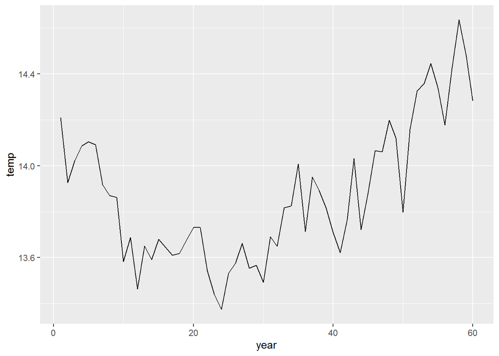

```r
temp<- split(data$sst, (ceiling(seq_along(data$sst)/(nrow(data)/60))))
temp <- lapply(temp, function(x) Reduce(`+`, x)/length(x) )
year = seq(length(temp))
df <- do.call(rbind, Map(data.frame, temp=temp, size=herring_size,year = year))
ggplot(df, aes(year)) +
  geom_line(aes(y = temp))
```

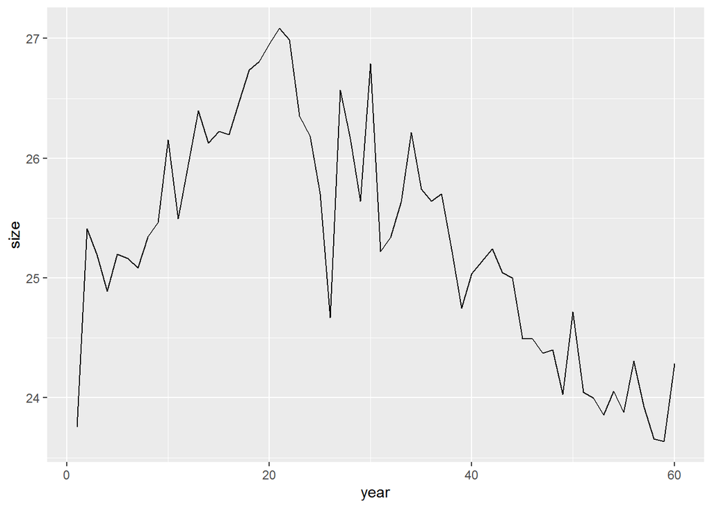

```r
ggplot(df, aes(year)) +
  geom_line(aes(y = size))
```

Lustrzany obraz wykresów potwierdza stwierdzoną wcześniej ujemną korelację.

# 10 Wnioski

Analiza statystyczna, wizualizacja danych oraz wytrenowanie modelu predykcyjnego pozwoliło potwierdzić spadek w rozmiarze śledzia na przestrzeni lat; określić moment, w którym ten trend nastąpił oraz co miało na niego największy wpływ. Zbadanie korealcji pomiędzy atrybutami pozwoliło usunąć z dalszej analizy mało znaczące atrybuty.